# Uninsured in America: How Income, Employment, and Demographics Shape Coverage

Author

Alasya Zeweldi

Introduction to Project:

Access to health insurance is a key determinant of health outcomes and financial security. This project explores which demographic and socioeconomic factors are associated with having or lacking health insurance, using individual-level microdata from the American Community Survey (ACS) to identify patterns in insurance access across the U.S. Understanding which groups are less likely to be insured can help target outreach efforts, inform policy interventions, and reduce disparities in access to care.

| Data cleaning and Preparation: |
| --- |
| The dataset comes from the 2021 American Community Survey (ACS), accessed through IPUMS USA as a custom microdata extract. IPUMS is an online platform that provides public-use census and survey data f… |
| To prepare the data for analysis, I filtered out invalid responses and missing values. For example, I removed cases with HHINCOME coded as 9999999 and dropped rows where sex, marital status, employmen… |

```r
# Loading and cleaning data
library(tidyverse)
hcov_data <- read_csv("hcov_data.csv")
head(hcov_data )
```

```
# A tibble: 6 × 13
   YEAR HHINCOME   SEX   AGE MARST  RACE HISPAN CITIZEN HCOVANY HCOVPRIV HCOVPUB
  <dbl>    <dbl> <dbl> <dbl> <dbl> <dbl>  <dbl>   <dbl>   <dbl>    <dbl>   <dbl>
1  2021  9999999     1    85     2     1      0       0       2        2       2
2  2021  9999999     2    67     5     2      0       0       2        1       2
3  2021  9999999     1    74     5     1      0       0       2        1       2
4  2021  9999999     1    16     6     1      0       0       2        1       2
5  2021  9999999     1    83     4     1      0       0       2        1       2
6  2021  9999999     2    19     6     1      0       0       2        2       1
# ℹ 2 more variables: EMPSTAT <dbl>, VETSTAT <dbl>
```

```r
# Cleaning and recode
data <- hcov_data %>%
  filter(
    HHINCOME != 9999999,
    SEX != 9,
    MARST != 9,
    HISPAN != 9,
    !EMPSTAT %in% c(0, 9),
    !VETSTAT %in% c(0, 9)
  ) %>%
  mutate(
    has_insurance = ifelse(HCOVANY == 2, 1, 0),
    private_insurance = HCOVPRIV,
    public_insurance  = HCOVPUB,
    marital_status    = MARST,
    SEX = case_when(SEX == 1 ~ "Male", SEX == 2 ~ "Female"),
    marital_status = case_when(MARST %in% 2:8 ~ 0, TRUE ~ 1),   # 1 = married, 0 = not
    HISPAN = case_when(HISPAN %in% 2:4 ~ 1, TRUE ~ 0),          # 1 = Hispanic
    EMPSTAT = case_when(EMPSTAT %in% 2:3 ~ 0, TRUE ~ 1),        # 1 = employed
    VETSTAT = case_when(VETSTAT == 2 ~ 1, VETSTAT == 1 ~ 0, TRUE ~ NA_real_) # 1 = veteran
  ) %>%
  select(-HCOVANY, -HCOVPRIV, -HCOVPUB, -MARST)
```

EDA

Exploratory Data Analysis

Before jumping into formal models, I explored basic patterns in the data to get a clearer picture of who has health insurance and who doesn’t. The analysis centers on the new variable `has_insurance`, which indicates whether someone has any form of health coverage, public or private.

To visualize these relationships, I use bar plots and calculated proportions to see which groups have the highest uninsured rates. This helps identify potential disparities and guides which variables matter most in the modeling stage.

- `1` = has insurance
- `0` = no insurance

I will also explore how coverage varies across key demographic and socioeconomic factors, including:

- `HHINCOME`: total household income
- `EMPSTAT`: employment status (employed or not)
- `RACE` and `HISPAN`: race and Hispanic/Latino origin
- `VETSTAT`: veteran status
- `AGE`, `SEX`, and `marital_status`: core demographic characteristics

**Statistical Hypothesis:**

To test the relationship between health insurance coverage and demographic and socioeconomic factors, I set up the following hypotheses:

**Null hypothesis (H₀):** None of the predictors are significantly associated with whether someone has insurance. H₀: β₁ = β₂ = ⋯ = βₖ = 0 (no predictor matters)

**Alternative hypothesis (H₁)**: At least one predictor is significantly associated with insurance status. H₁: at least one βⱼ ≠ 0 (at least one predictor matters)

I test these hypotheses using logistic regression, which is appropriate since the outcome variable (`has_insurance`) is binary.

```r
table(data$has_insurance)
```

```
      0       1
 563289 7168523
```

| **Statistical Analysis** |
| --- |
| **Before I analyze this further, it’s important to clarify who has insurance in our sample:** - **7.2 million** people have insurance (`has_insurance == 1`) - **563,000** people do not (`has_insurance… |

```r
# Proportion uninsured by income group

data |>
  group_by(HHINCOME) |>
  summarize(
    total = n(),
    uninsured = sum(has_insurance == 0),
    proportion_uninsured = uninsured / total
  ) |>
  arrange(desc(proportion_uninsured)) |>

  glimpse()
```

```
Rows: 45,702
Columns: 4
$ HHINCOME             <dbl> -12800, -11800, -9800, -8250, -7700, -4970, -3290…
$ total                <int> 2, 2, 2, 1, 1, 1, 3, 1, 2, 1, 1, 1, 1, 2, 1, 1, 1…
$ uninsured            <int> 2, 2, 2, 1, 1, 1, 3, 1, 2, 1, 1, 1, 1, 2, 1, 1, 1…
$ proportion_uninsured <dbl> 1, 1, 1, 1, 1, 1, 1, 1, 1, 1, 1, 1, 1, 1, 1, 1, 1…
```

Insights:

```r
# Proportion with insurance by income group


data |>
  group_by(HHINCOME) |>
  summarize(
    total = n(),
    uninsured = sum(has_insurance == 0),
    proportion_uninsured = uninsured / total) |>
  arrange(proportion_uninsured) |>
  filter(total >= 10) |>
  slice_head(n = 30)
```

```
# A tibble: 30 × 4
   HHINCOME total uninsured proportion_uninsured
      <dbl> <int>     <int>                <dbl>
 1    -5800    11         0                    0
 2    -3200    16         0                    0
 3     1070    28         0                    0
 4     1270    16         0                    0
 5     1780    24         0                    0
 6     1830    23         0                    0
 7     2210    18         0                    0
 8     2360    31         0                    0
 9     2410    18         0                    0
10     2480    19         0                    0
# ℹ 20 more rows
```

Further investigation:

That said, this doesn’t yet show the tipping point where people stop qualifying for public programs but still can’t afford private insurance. To understand that drop-off, I scan higher income ranges where the proportion uninsured might start rising again.

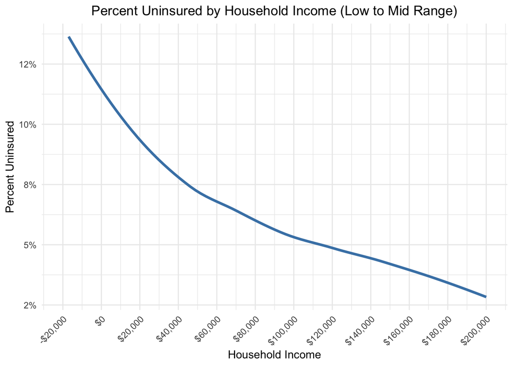

```r
#Line graph: Low to middle Income and insurance rates

data |>
  filter(HHINCOME >= -20000, HHINCOME <= 200000) |>  # Expand to include some negative income and focus on lower ranges
  group_by(HHINCOME) |>
  summarize(
    total = n(),
    uninsured = sum(has_insurance == 0),
    proportion_uninsured = uninsured / total
  ) |>
  arrange(HHINCOME) |>
  ggplot(aes(x = HHINCOME, y = proportion_uninsured)) +
  geom_smooth(method = "loess", se = FALSE, color = "steelblue", linewidth = 1.2) +
  scale_x_continuous(
    labels = scales::dollar_format(),
    limits = c(-20000, 200000),  # Adjust range to highlight key zone
    breaks = seq(-20000, 200000, by = 20000)  # Ticks every $20k for readability
  ) +
  scale_y_continuous(labels = scales::percent_format(accuracy = 1)) +
  labs(
    title = "Percent Uninsured by Household Income (Low to Mid Range)",
    x = "Household Income",
    y = "Percent Uninsured"
  ) +
  theme_minimal() +
  theme(
    plot.title = element_text(hjust = 0.5),
    axis.text.x = element_text(angle = 45, hjust = 1)
  )
```

Low-to-mid income graph:

As household income increases, the percent of people without health insurance declines. The drop is steepest at lower income levels: moving from $0 to $60,000 produces a sharp reduction in the uninsured rate. Beyond that, the curve flattens, meaning higher income continues to reduce the likelihood of being uninsured, but the gains are smaller.

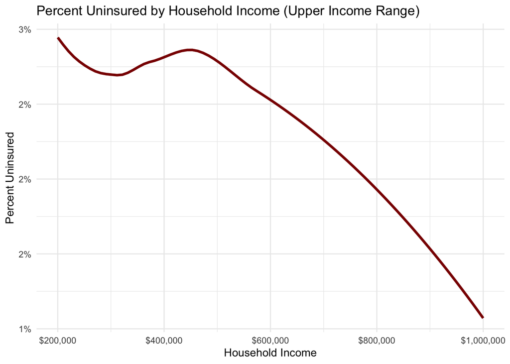

```r
#Line graph: Higer Income and insurance rates:

data |>
  filter(HHINCOME >= 200000, HHINCOME <= 1000000) |>
  group_by(HHINCOME) |>
  summarize(
    total = n(),
    uninsured = sum(has_insurance == 0),
    proportion_uninsured = uninsured / total
  ) |>
  arrange(HHINCOME) |>
  ggplot(aes(x = HHINCOME, y = proportion_uninsured)) +
  geom_smooth(method = "loess", se = FALSE, color = "darkred", linewidth = 1.2) +
  scale_x_continuous(labels = scales::dollar_format()) +
  scale_y_continuous(labels = scales::percent_format(accuracy = 1)) +
  labs(
    title = "Percent Uninsured by Household Income (Upper Income Range)",
    x = "Household Income",
    y = "Percent Uninsured") +  theme_minimal()
```

Upper income graph:

This graph explores the relationship between high household income and the likelihood of being uninsured. At first glance, I might expect the uninsured rate to continue dropping as income rises. But the pattern here is more nuanced: the proportion of people without insurance slightly fluctuates between $200,000 and $500,000, hovering around 2.5% to 3%. This may suggest that some higher-income individuals choose not to carry insurance possibly because they can afford to pay out-of-pocket or are self-employed and opt out of traditional plans.

However, after about the $500,000 mark, the uninsured rate starts to fall again, reaching close to 1% by $1 million in income. This could reflect increased access to employer-provided benefits among very high earners or greater willingness to pay for private plans.

In short, while income is still negatively correlated with being uninsured overall, this upper range reveals some complexity particularly among those earning enough to self-insure or selectively opt out.

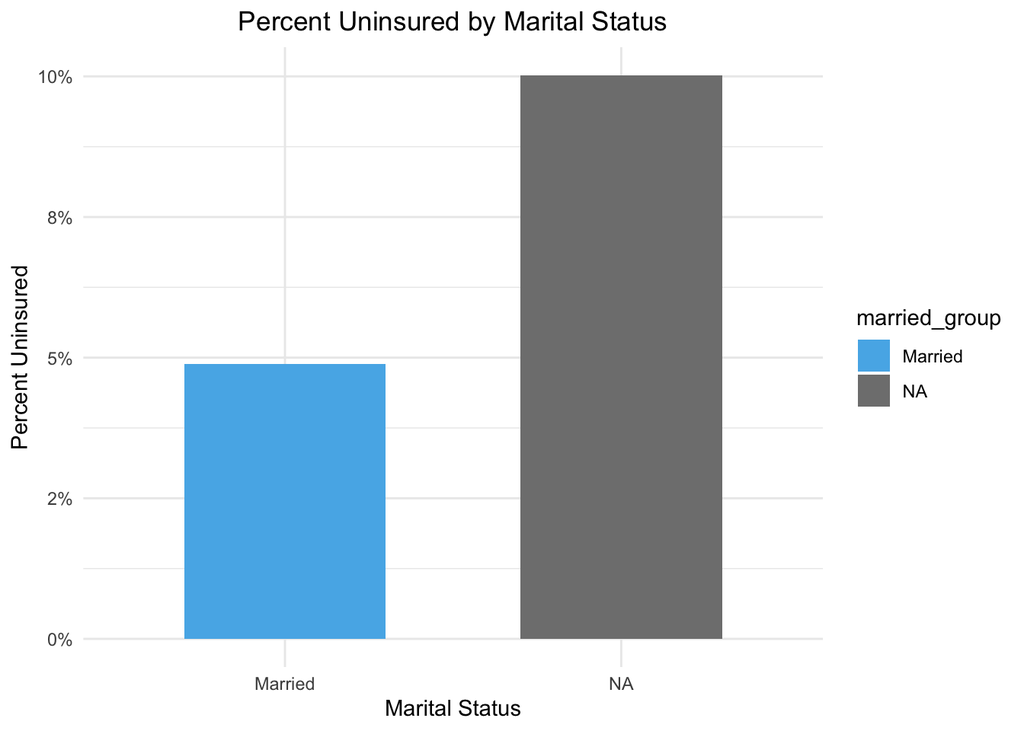

```r
#graph of:Insurance Rates and Marital Status

data |>
  filter(!is.na(marital_status)) |>
  mutate(married_group = case_when(
    marital_status %in% c(1, 2, 3) ~ "Married",         # Includes Separated
    marital_status %in% c(4, 5, 6) ~ "Not Married"      # Divorced, Widowed, Never Married
  )) |>
  group_by(married_group) |>
  summarize(
    total = n(),
    uninsured = sum(has_insurance == 0),
    proportion_uninsured = uninsured / total
  ) |>
  ggplot(aes(x = married_group, y = proportion_uninsured, fill = married_group)) +
  geom_col(width = 0.6) +
  scale_y_continuous(labels = scales::percent_format(accuracy = 1)) +
  scale_fill_manual(values = c("Married" = "#56B4E9", "Not Married" = "#E69F00")) +
  labs(
    title = "Percent Uninsured by Marital Status",
    x = "Marital Status",
    y = "Percent Uninsured"
  ) +
  theme_minimal() +
  theme(plot.title = element_text(hjust = 0.5))
```

| **Insurance Rates and** Marital status**:** |
| --- |
| The chart shows that married individuals are less likely to be uninsured than those who are not married. This difference may partly reflect access to a spouse’s employer-sponsored health insurance, or… |

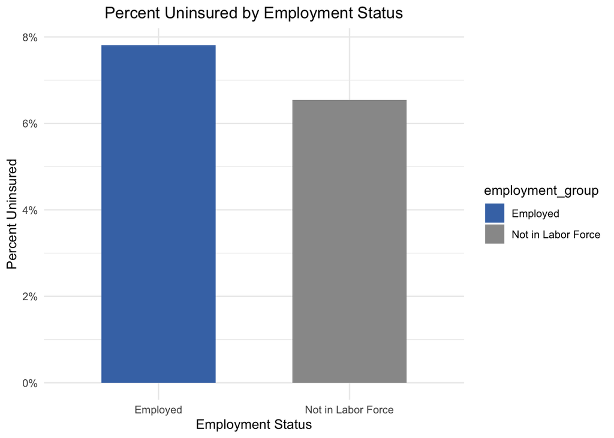

```r
#percent uninsured by employment status

data |>
  filter(!is.na(EMPSTAT)) |>
  mutate(employment_group = case_when(
    EMPSTAT == 1 ~ "Employed",
    EMPSTAT == 0 ~ "Not in Labor Force")) |>
  group_by(employment_group) |>
  summarize(
    total = n(),
    uninsured = sum(has_insurance == 0),
    proportion_uninsured = uninsured / total) |>
  ggplot(aes(x = employment_group, y = proportion_uninsured, fill = employment_group)) +
  geom_col(width = 0.6) +
  scale_y_continuous(labels = scales::percent_format(accuracy = 1)) +
  scale_fill_manual(values = c("Employed" = "#4575b4", "Not in Labor Force" = "#999999")) +
  labs(
    title = "Percent Uninsured by Employment Status",
    x = "Employment Status",
    y = "Percent Uninsured") + theme_minimal() +
  theme(plot.title = element_text(hjust = 0.5))
```

Employment insights:

While employed individuals might be expected to have better access to insurance, the uninsured rate is actually slightly higher among them than among those not in the labor force. The “not in labor force” group includes retirees with Medicare, students covered through their universities, and individuals on disability who often qualify for public insurance programs. Employed individuals, on the other hand, may be in part-time roles, gig economy jobs, or positions that don’t offer employer-sponsored coverage, making them more likely to be uninsured.

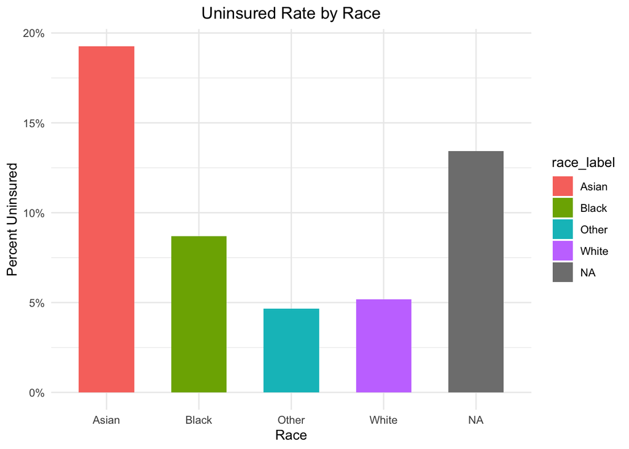

```r
#race bar chart: showing perecent Uninsured

data %>%
  filter(!is.na(RACE)) %>%
  mutate(race_label = case_when(
    RACE == 1 ~ "White",
    RACE == 2 ~ "Black",
    RACE == 3 ~ "Asian",
    RACE == 4 ~ "Other"
  )) %>%
  group_by(race_label) %>%
  summarize(
    total = n(),
    uninsured = sum(has_insurance == 0),
    proportion_uninsured = uninsured / total
  ) %>%
  ggplot(aes(x = race_label, y = proportion_uninsured, fill = race_label)) +
  geom_col(width = 0.6) +
  scale_y_continuous(labels = scales::percent_format(accuracy = 1)) +
  labs(
    title = "Uninsured Rate by Race",
    x = "Race",
    y = "Percent Uninsured"
  ) +
  theme_minimal() +
  theme(plot.title = element_text(hjust = 0.5))
```

Insights:

This graph shows that Americans identified as “Asian” have the highest uninsured rate, at nearly 20%. It’s important to remember that the Asian category is broad and includes many different communities with varied experiences. For example, research shows that Korean Americans are more likely to be self-employed or work for small businesses, which tend to offer less access to employer-sponsored insurance. Without more detailed subgroup data, these variations get combined under a single label

The uninsured rates for Black and White Americans are lower, around 8-9% and 5%, respectively. These differences could reflect disparities in job types, income, public coverage access, and structural factors tied to employment. The “Other” category, at under 5%, includes individuals who don’t identify with the listed racial groups and is difficult to interpret without more context

The NA group likely includes individuals who are multiracial, chose not to identify with the listed categories, or were not clearly classified. Since race is often simplified in large surveys, this group’s higher uninsured rate (~13%) may reflect limitations in how racial identity is recorded.

Finally, there is no Hispanic or Latino category shown because Census-style data records ethnicity separately from race. Many Hispanic individuals may appear under any of the racial groups above, which is why the next graph uses the `HISPAN` variable to look at this population directly.

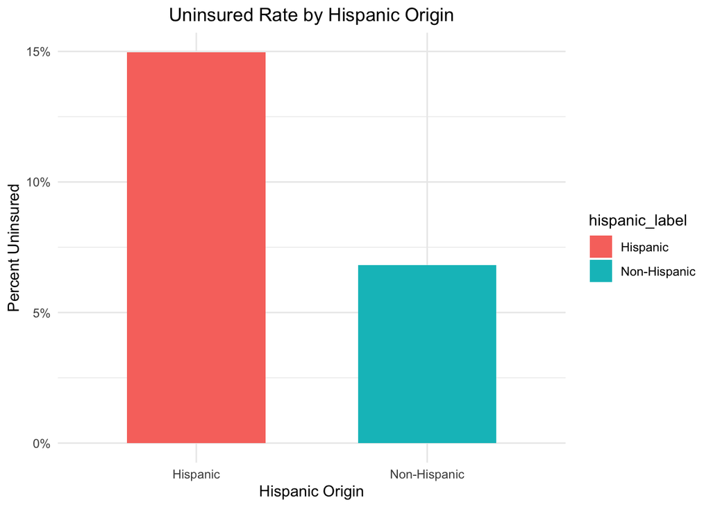

```r
# percent uninsured by Hispanic origin
data %>%
  filter(!is.na(HISPAN)) %>%
  mutate(hispanic_label = case_when(
    HISPAN == 1 ~ "Hispanic",
    HISPAN == 0 ~ "Non-Hispanic"
  )) %>%
  group_by(hispanic_label) %>%
  summarize(
    total = n(),
    uninsured = sum(has_insurance == 0),
    proportion_uninsured = uninsured / total
  ) %>%
  ggplot(aes(x = hispanic_label, y = proportion_uninsured, fill = hispanic_label)) +
  geom_col(width = 0.6) +
  scale_y_continuous(labels = scales::percent_format(accuracy = 1)) +
  labs(
    title = "Uninsured Rate by Hispanic Origin",
    x = "Hispanic Origin",
    y = "Percent Uninsured"
  ) +
  theme_minimal() +
  theme(plot.title = element_text(hjust = 0.5))
```

insights:

The data show a clear disparity in coverage between Hispanic and non-Hispanic individuals. In this sample, nearly 1 in 6 Hispanic respondents lack health insurance, more than double the rate among non-Hispanic individuals. Many Hispanic Americans work in sectors like construction, hospitality, and agriculture, industries that often don’t offer employer-based coverage. In addition, immigration status, language barriers, and limited access to public assistance programs may make it harder to enroll in or qualify for insurance, even when technically eligible.

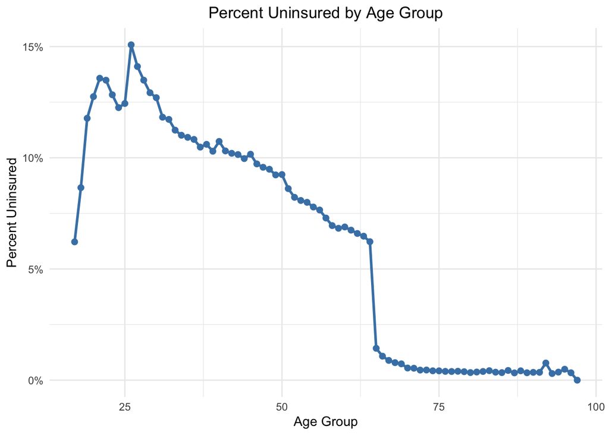

```r
# Age graph: showing percent uninsured with clean labels

data |>
  group_by(AGE) |>
  summarize(
    total = n(),
    uninsured = sum(has_insurance == 0),
    proportion_uninsured = uninsured / total
  ) |>
  ggplot(aes(x = AGE, y = proportion_uninsured, group = 1)) +
  geom_line(color = "steelblue", size = 1) +
  geom_point(color = "steelblue", size = 2) +
  scale_y_continuous(labels = scales::percent_format(accuracy = 1)) +
  labs(
    title = "Percent Uninsured by Age Group",
    x = "Age Group",
    y = "Percent Uninsured"
  ) +
  theme_minimal() +
  theme(plot.title = element_text(hjust = 0.5))
```

Age and Insurance coverage: What the graph tells us

The uninsured rate is highest among young adults aged 20-29, at around 13%, and steadily declines with age. Rates fall sharply starting in the 60s, reaching near zero for those 70 and older. This likely reflects Medicare eligibility after age 65, while younger adults, especially those just out of school or in early-career or part-time jobs, may lack employer-based coverage or delay getting insured. The pattern highlights how age-based programs like Medicare significantly improve coverage among older populations.

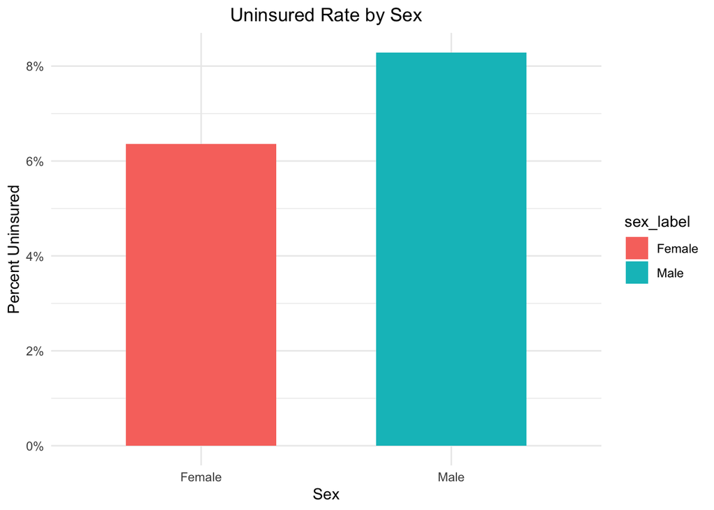

```r
# Gender/Sex graph: Showing percent uninsured
data |>
  filter(!is.na(SEX)) |>
  mutate(sex_label = case_when(
    SEX == "Male" ~ "Male",
    SEX == "Female" ~ "Female",
    TRUE ~ "Other/Unknown"  # just in case there's anything weird
  )) |>
  group_by(sex_label) |>
  summarize(
    total = n(),
    uninsured = sum(has_insurance == 0),
    proportion_uninsured = uninsured / total
  ) |>
  ggplot(aes(x = sex_label, y = proportion_uninsured, fill = sex_label)) +
  geom_col(width = 0.6) +
  scale_y_continuous(labels = scales::percent_format(accuracy = 1)) +
  labs(
    title = "Uninsured Rate by Sex",
    x = "Sex",
    y = "Percent Uninsured"
  ) +
  theme_minimal() +
  theme(plot.title = element_text(hjust = 0.5))
```

**Analysis: Insurance rates by Sex**

Males have a higher uninsured rate (just over 8%) than females (about 6.4%). Men are more likely to work in jobs without benefits, such as gig or seasonal work, and may be less likely to seek out or enroll in public insurance programs. Women, especially those with children, may qualify for programs like Medicaid at higher rates. These patterns suggest that employment type and policy eligibility help explain coverage differences by sex.

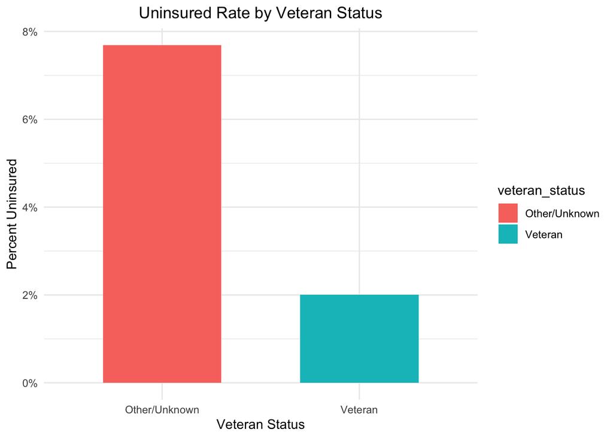

```r
# veteran status: showing percent uninsured

data |>
  filter(!is.na(VETSTAT)) |>
  mutate(veteran_status = case_when(
    VETSTAT == 1 ~ "Veteran",
    VETSTAT == 2 ~ "Non-Veteran",
    TRUE ~ "Other/Unknown"
  )) |>
  group_by(veteran_status) |>
  summarize(
    total = n(),
    uninsured = sum(has_insurance == 0),
    proportion_uninsured = uninsured / total
  ) |>
  ggplot(aes(x = veteran_status, y = proportion_uninsured, fill = veteran_status)) +
  geom_col(width = 0.6) +
  scale_y_continuous(labels = scales::percent_format(accuracy = 1)) +
  labs(
    title = "Uninsured Rate by Veteran Status",
    x = "Veteran Status",
    y = "Percent Uninsured") +  theme_minimal() +
  theme(plot.title = element_text(hjust = 0.5))
```

| Veteran Status: How that effects insurance rates |
| --- |
| Veterans have a significantly lower uninsured rate than the “Other/Unknown” group, likely due to their access to government-supported healthcare through the VA system. Eligibility for veteran-specific… |

```r
model <- glm(formula = has_insurance ~ HHINCOME + EMPSTAT + RACE + HISPAN + VETSTAT + AGE + SEX + marital_status,
             family = binomial,
             data = data)

summary(model)
```

```
Call:
glm(formula = has_insurance ~ HHINCOME + EMPSTAT + RACE + HISPAN +
    VETSTAT + AGE + SEX + marital_status, family = binomial,
    data = data)

Coefficients:
                 Estimate Std. Error z value Pr(>|z|)
(Intercept)     9.511e-01  5.467e-03  173.97   <2e-16 ***
HHINCOME        6.047e-06  2.301e-08  262.81   <2e-16 ***
EMPSTAT         4.044e-02  3.159e-03   12.80   <2e-16 ***
RACE           -1.168e-01  5.208e-04 -224.22   <2e-16 ***
HISPAN         -2.270e-01  4.976e-03  -45.62   <2e-16 ***
VETSTAT         1.013e+00  9.959e-03  101.67   <2e-16 ***
AGE             3.003e-02  8.900e-05  337.45   <2e-16 ***
SEXMale        -3.525e-01  2.906e-03 -121.30   <2e-16 ***
marital_status  2.248e-01  3.178e-03   70.75   <2e-16 ***
---
Signif. codes:  0 '***' 0.001 '**' 0.01 '*' 0.05 '.' 0.1 ' ' 1

(Dispersion parameter for binomial family taken to be 1)

    Null deviance: 4035358  on 7731811  degrees of freedom
Residual deviance: 3613425  on 7731803  degrees of freedom
AIC: 3613443

Number of Fisher Scoring iterations: 6
```

Logistic regression explanation:

All of the predictors in the model are statistically significant, but some have a much stronger practical impact than others. Being a veteran shows the largest positive effect, with a coefficient close to 1, meaning veterans are far more likely to have health insurance. This makes sense given the benefits available through VA healthcare and other federal programs for those who have served. Employment and marital status also increase the likelihood of being insured, reflecting how many people get coverage through work or a spouse. Being Hispanic is associated with a lower chance of having insurance, even after accounting for income and job status, which supports the earlier exploratory findings. Men are also less likely than women to be insured.

Final conclusion: